# Weight Lifting Exercises Data set - Analysis and Report

Ganesh Sethuraman

July 26, 2015

# Abstract

This human activity recognition is applied to the Weight Lifting Exercises data set is to investigate “how (well)” an activity was performed by the wearer. The users are classified as A, B, C, D, E. Here ‘A’ means someone who is doing the weight lifting correctly, other classes indicate a specific mistake the user is doing while doing weight lifting.

# Load the Data (with some Cleansing)

While browsing the data set (using str function) it is evident that, there are many numeric fields that are presented as string. When we looked deeper there were specific string which needs to considered as **`NA`**.

```r
library("caret")
library("dplyr")
```

```r
set.seed(1729) # Ramamnujam number
pmlTrain = read.csv("pml-training.csv", na.strings=c("NA","NaN", " ", "#DIV/0!"))
pmlTest = read.csv("pml-testing.csv", na.strings=c("NA","NaN", " ", "#DIV/0!"))
#str(pmlTrain,list.len = 999)
```

# Exploratory Analysis

```r
summary(pmlTrain)
```

[output not shown]

# Preprocess the data set

There are 3 steps in the process

1. Remove the Near Zero variance columns (removes 29 columns)
2. Remove the columns which has 95% of values as NA (removes 77 additional columns)
3. Remove the columns that doesn’t make sense in the weight lifting domain. In this case, since we do want to be training the data based on the (Removes additional 5, in total 111 columns is of interest):
   - user name (as training set shouldn’t tuned to the user name to avoid issues in the User)
   - Serial number and dates of the observation are irrelevant to this exercise.

```r
# Remove Near Zero Variance columns
dim(pmlTrain)
```

```
## [1] 19622   160
```

```r
nzvPml = nearZeroVar(pmlTrain[sapply(pmlTrain, is.numeric)])
pmlTrain.filtered = pmlTrain[, -nzvPml]
pmlTest.filtered = pmlTest[, -nzvPml]

# remove all NA column
naCols = colSums(is.na(pmlTrain.filtered))<nrow(pmlTrain.filtered)*0.95
pmlTrain.filtered.noNA <- pmlTrain.filtered[,naCols]
pmlTest.filtered.noNA <- pmlTest.filtered[,naCols]

# Remove varibles that does'nt make sense in the Weight Lifting Exercises Dataset
dropCol = c("user_name","X", "raw_timestamp_part_1", "raw_timestamp_part_2", "cvtd_timestamp")
pmlTrain.filtered.2 = pmlTrain.filtered.noNA[,!(names(pmlTrain.filtered.noNA) %in% dropCol)]
pmlTest.filtered.2 = pmlTest.filtered.noNA[,!(names(pmlTest.filtered.noNA) %in% dropCol)]
dim(pmlTrain.filtered.2)
```

```
## [1] 19622    49
```

```r
dim(pmlTest.filtered.2)
```

```
## [1] 20 49
```

# Splitting the data set

The training data is further split into training set and validation data, so that out-of-sample accuracy can be calculated. This validation data set can be used for model comparison as well.

```r
inTrain = createDataPartition(pmlTrain.filtered.2$classe, p=0.7, list=FALSE)

trainingPmlTrain = pmlTrain.filtered.2[inTrain,]
validationPmlTrain = pmlTrain.filtered.2[-inTrain,]
```

# Model Creation - Boosting technique

```r
library(doParallel)
registerDoParallel(cores=3)
gbmfitControl <- trainControl(## 10-fold CV
                           method = "repeatedcv",
                           number = 10,
                           ## repeated 3 times
                           repeats = 3)
modFitboost = train(trainingPmlTrain$classe ~., method="gbm", trControl = gbmfitControl, data=trainingPmlTrain, verbose = FALSE)
print(modFitboost$results$Accuracy[1])
```

```
## [1] 0.7422071
```

```r
registerDoSEQ()
```

The accuracy of Gradient boosting based model is mentioned below.

**In-Sample Accuracy: 0.7422071**

# Variable importance & Out of Sample Error (Validation)

Make sure the variables that are important are intuitively important. Please find the confusion matrix table below. This shows that predicted value and actual values on the validation set is more or less the same (high accuracy).

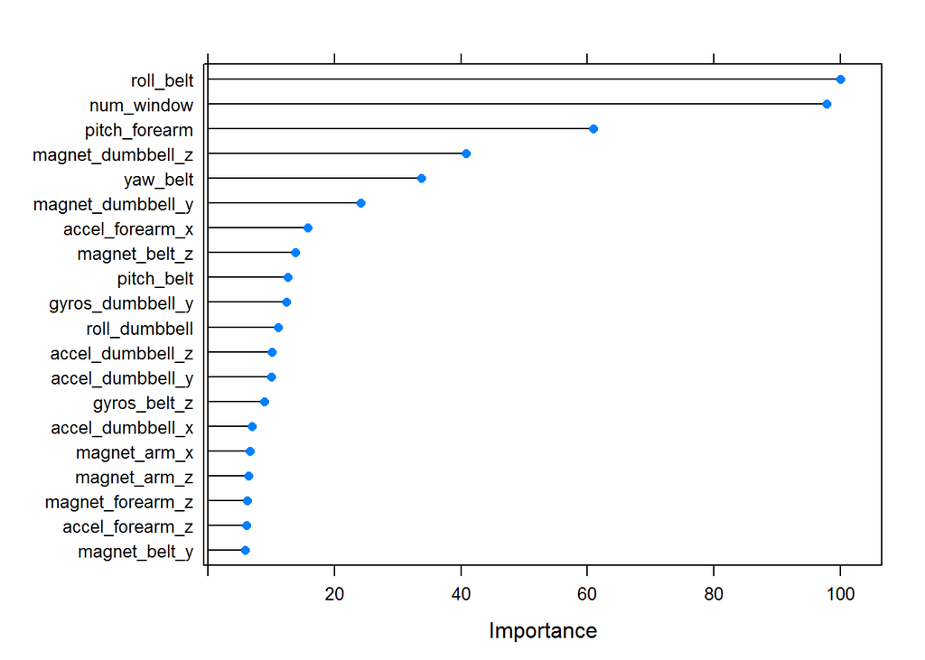

```r
gbmImp <- varImp(modFitboost, scale = TRUE)
plot(gbmImp, top = 20)
```

```r
#Testing the prediction with Validation set
predValidation = predict(modFitboost, newdata = validationPmlTrain)
length(predValidation)
```

[output not shown]

```r
mat = confusionMatrix(predValidation, validationPmlTrain$classe)
mat$table
```

[output not shown]

**Out-of-Sample Accuracy: 0.972093**. Note that out-of-sample accuracy is better than in-sample accuracy from the model in this case. If accuracy is high, note that sample error is low.

# Actual Testing with Test data

Now that we are confident of the out-of-sample accuracy is high. We are good to test it with the actual test data.

```r
#Testing the prediction with REAL Test set
pmlTest.filtered.2$predTest = predict(modFitboost, newdata = pmlTest.filtered.2)
length(pmlTest.filtered.2$predTest)
```

```
## [1] 20
```

```r
pmlTest.filtered.2$predTest
```

```
##  [1] B A B A A E D B A A B C B A E E A B B B
## Levels: A B C D E
```

# Submission files

```r
answers = pmlTest.filtered.2$predTest

#create the submission files
pml_write_files = function(x){
  n = length(x)
  for(i in 1:n){
    filename = paste0("problem_id_",i,".txt")
    write.table(x[i],file=filename,quote=FALSE,row.names=FALSE,col.names=FALSE)
  }
}
pml_write_files(answers)
```

# References

Velloso, E.; Bulling, A.; Gellersen, H.; Ugulino, W.; Fuks, H. Qualitative Activity Recognition of Weight Lifting Exercises. Proceedings of 4th International Conference in Cooperation with SIGCHI (Augmented Human ’13) . Stuttgart, Germany: ACM SIGCHI, 2013.

Read more: http://groupware.les.inf.puc-rio.br/har#literature#ixzz3gxZzwiwE

==========